# Update 2 terra indigena 20220925

Edgar Cifuentes

05/10/2022

Here are some updates after getting data from the layers for the matching analysis…

The main aim is to modify Fig 5 where ILs are compared with their buffers, but instead compare ILs with controls from the matching analysis. Data from buffers excludes neighboring ILs, but the reviewers suggested to exclude Protected Areas (PAs) as well. Then, besides the data for the matching pairs, I extracted again data for each buffer excluding PAs.

# Preparing data

Layers from mapbiomas (collection 3 and 6) and relevant variables (ie, accessibility to cities, distance to roads, human population density, biome type, and PAs) were resampled to 1-km resolution images masked for the ‘legal Amazon’. Then, data for each 1-km grid (ie, pixel) was extracted for all layers excluding PAs and selecting only the the pixels having 80% of natural vegetation cover at the start of the time period (ie, 1985). Natural cover was calculated from the re-classified transitions shown in the previous tab. Since we are using transition layers of mapbiomas (not the land cover layers), natural vegetation cover is the sum of two transitions: what remained natural plus what was transformed from natural. Then, natural vegetation cover in each 1-km pixel was divided by its area (which varies slightly from 1) to get the proportion.

$${Proportion\ of\ natural\ land} = \frac{transformed + remain}{area}$$

In the case of buffers, mapbiomas data was extracted again for each of them. Then, there is data for two types of buffers:

1. as in the original methodology, only excluding neighboring ILs, and
2. excluding PAs as well.

An important difference now compared to the original methodology, is that the basic data units are pixels, even though they’re aggregated after for each IL and its respective matching control plus buffers. Therefore, only the pixels having 80% of natural cover were selected (and aggregated after) now. Before, mapbiomas data was not extracted by 1-km pixels but to the whole IL and buffers.

When excluding PA pixels, some ILs and/or buffers were filtered out as some PAs overlap completely (or partially). There are ILs completely surrounded by PAs and/or other ILs, so the whole buffer would not have any data. When selecting only 80% cover pixels, some other ILs get excluded as well.

> *TODO:*
> > - how much IL area and how many ILs where excluded when excluding PAs.
> > - how much buffer area and how many buffers were excluded when excluding neighboring ILs and with PAs.
> > - how much IL area and how many ILs where excluded when filtering above 80% cover.
> > - how much buffer area and how many buffers were excluded when when filtering above 80% cover.

# Matching analysis

After filtering out pixels in PAs and having less than 80% cover, the table was ready for the matching analysis. For each IL pixel, this analysis matches another pixel under similar characteristics outside the IL. The characteristics (ie, variables) we used are:

1. accessibility to cities
2. distance to roads
3. human population density
4. biome type

# Data aggregation for each IL

Mapbiomas data were aggregated for each IL, its respective matched control and buffers. The response variable in each of them, is the proportion of natural vegetation loss, which is calculated as in option 1 in previous tab:

$${Percentage\ of\ natural\ vegetation\ loss} = \frac{transformed} {transformed + remain} *100$$

# Figure 5. Boxplots

This is the original figure:

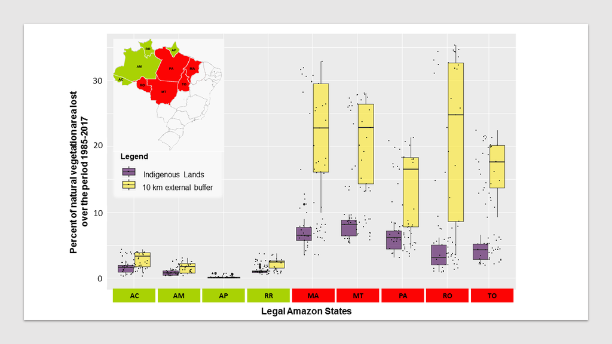

Data was extracted from mapbiomas collection 3 (same as the original methodology, up to 2017) and collection 6 (up to 2020). Besides having data for both collections, there are three options for this figure:

## Option 1

Add another panel comparing ILs and their controls, but I’m less convinced with this option because IL boxplots are not same as the original figure (see above) because all of the exclusions (ie, PAs and 80% cover).

### Collection 3

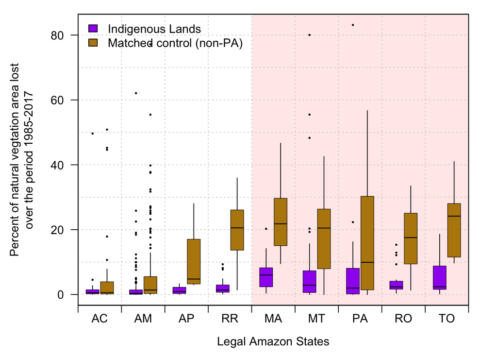

### Collection 6

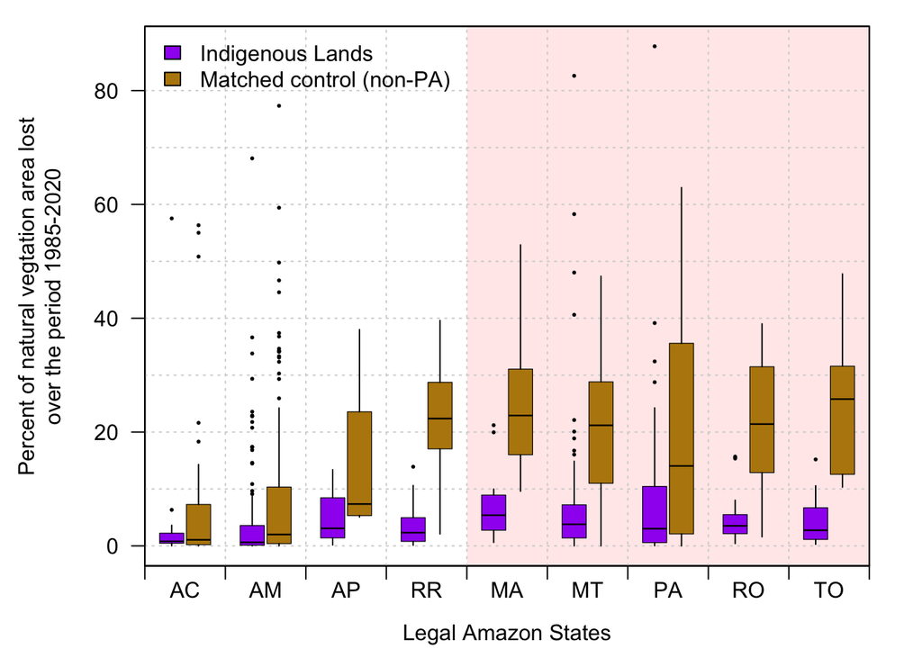

## Option 2

2. Replace the figure with a new one having ILs, controls, and buffers:

### Collection 3

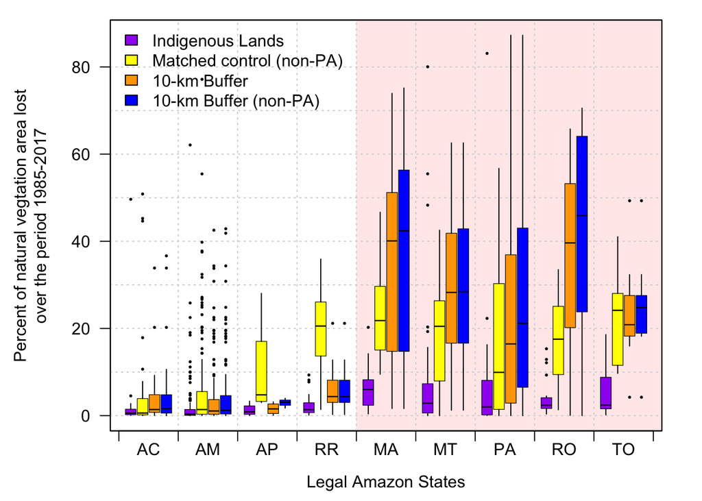

### Collection 6

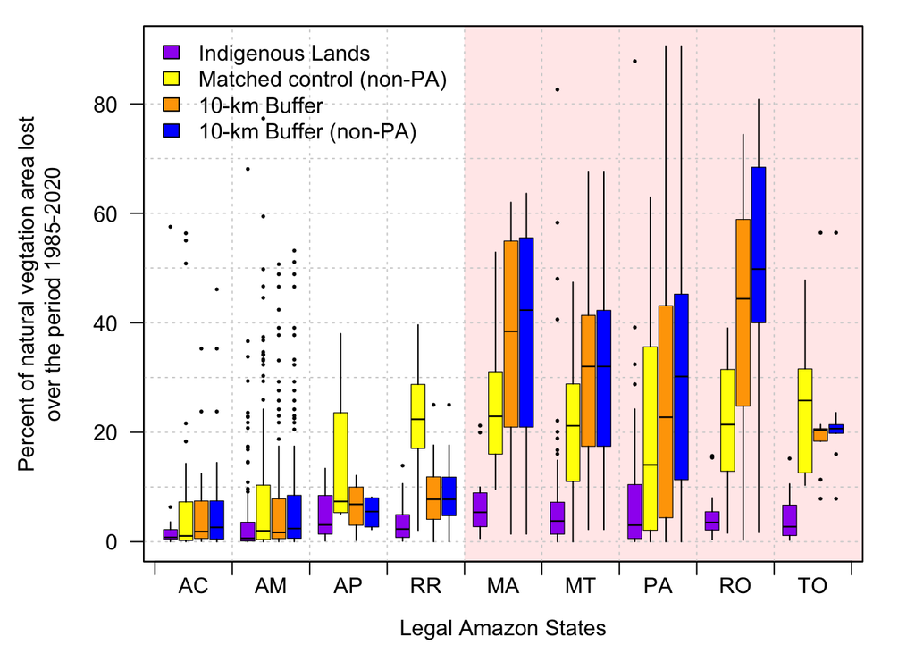

## Option 3

Any suggested.